# Marginal Gain Per Check 2020 Unemployed

[Fan Wang](https://fanwangecon.github.io/)

2020-08-07

# 1 2020 V and C with Unemployment

## 1.1 Test SNW_A4CHK_UNEMP_BISEC_VEC Defaults

Solve for Value/Policy in non-COVID years, then solve for covid year value/policy given covid shocks. COVID lasts one period.

```
mp_params = snw_mp_param('default_docdense', false, 'tauchen', true);
mp_params('beta') = 0.95;
mp_controls = snw_mp_control('default_test');
mp_controls('bl_print_vfi') = false;
mp_controls('bl_timer') = true;
[V_ss,~,cons_ss,~] = snw_vfi_main_bisec_vec(mp_params, mp_controls);

Completed SNW_VFI_MAIN_BISEC_VEC;SNW_MP_PARAM=default_docdense;SNW_MP_CONTROL=default_test;time=503.886
----------------------------------------
xxxxxxxxxxxxxxxxxxxxxxxxxxxxxxxxxxxxxxxx
CONTAINER NAME: mp_outcomes ND Array (Matrix etc)
xxxxxxxxxxxxxxxxxxxxxxxxxxxxxxxxxxxxxxxx
                i    idx    ndim     numel      rowN      colN           sum         mean       std      coefvari      min          max
                _    ___    ____    ________    ____    _________    ___________    _______    ______    ________    ________    __________

    V_VFI       1     1      6      4.37e+07     83     5.265e+05    -6.6619e+08    -15.245    21.865    -1.4343      -504.39    -0.0071775
    ap_VFI      2     2      6      4.37e+07     83     5.265e+05     1.3967e+09     31.962    36.426     1.1397            0        160.24
    cons_VFI    3     3      6      4.37e+07     83     5.265e+05     2.3276e+08     5.3263    8.4413     1.5848     0.036717        141.61

xxx TABLE:V_VFI xxxxxxxxxxxxxxxxxx
             c1         c2         c3         c4         c5        c526496      c526497      c526498      c526499      c526500
           _______    _______    _______    _______    _______    _________    _________    _________    _________    _________

    r1     -293.96    -293.57    -291.09    -285.44    -276.41      -4.3584      -4.2643      -4.1713      -4.0795      -3.9885
    r2     -284.42    -284.03    -281.55    -275.97    -267.24      -4.2519      -4.1612      -4.0717      -3.9832      -3.8955
    r3     -274.87    -274.48    -272.03    -266.62    -258.33      -4.1429      -4.0559      -3.9698      -3.8847      -3.8002
    r4     -265.22    -264.86    -262.58    -257.53    -249.74      -4.0309      -3.9475      -3.8649      -3.7833      -3.7017
    r5     -256.51    -256.17    -254.04     -249.3    -241.96      -3.9252      -3.8452      -3.7659      -3.6873      -3.6084
    r79    -13.642    -13.628    -13.535    -13.298    -12.896     -0.22092     -0.21058     -0.20086     -0.19173     -0.18315
    r80    -12.283    -12.269    -12.176    -11.939    -11.537     -0.16979     -0.16182      -0.1543     -0.14722     -0.14057
    r81    -10.605    -10.591    -10.498    -10.261    -9.8589     -0.11712     -0.11163     -0.10646     -0.10157     -0.09695
    r82    -8.3494    -8.3358    -8.2424    -8.0055    -7.6035    -0.065333    -0.062242     -0.05936    -0.056635    -0.054056
    r83    -5.0665    -5.0529    -4.9595    -4.7226    -4.3206    -0.020968    -0.019972    -0.019038    -0.018161    -0.017336

xxx TABLE:ap_VFI xxxxxxxxxxxxxxxxxx
           c1    c2        c3           c4           c5       c526496    c526497    c526498    c526499    c526500
           __    __    __________    _________    ________    _______    _______    _______    _______    _______

    r1     0     0     0.00051498    0.0066578    0.021589    112.13     117.67      123.4     129.31     135.72
    r2     0     0     0.00051498    0.0057684    0.020245    112.17     117.71     123.43     129.34     135.76
```

[output cut: 95 more lines]

```
----------------------------------------
xxxxxxxxxxxxxxxxxxxxxxxxxxxxxxxxxxxxxxxx
CONTAINER NAME: mp_container_map ND Array (Matrix etc)
xxxxxxxxxxxxxxxxxxxxxxxxxxxxxxxxxxxxxxxx
                         i    idx    ndim     numel      rowN      colN           sum           mean          std        coefvari        min           max
                         _    ___    ____    ________    ____    _________    ___________    __________    __________    ________    ___________    __________

    C_U                  1     1      6      4.37e+07     83     5.265e+05     2.2891e+08        5.2382        8.4439      1.612        0.022068        140.47
    C_U_minus_C_unemp    2     2      6      4.37e+07     83     5.265e+05          31259    0.00071531    0.00096113     1.3437     -2.3915e-08       0.00345
    V_U                  3     3      6      4.37e+07     83     5.265e+05    -6.8723e+08       -15.726        22.766    -1.4476         -545.38    -0.0071773
    V_U_minus_V_unemp    4     4      6      4.37e+07     83     5.265e+05     9.9746e+05      0.022825       0.19891     8.7143      1.8604e-07        18.184
    mn_MPC_unemp         5     5      6      4.37e+07     83     5.265e+05     9.0737e+06       0.20764         0.279     1.3437     -6.9419e-06        1.0015

mn_V_U_gain_check = V_U_2020 - V_unemp_2020;
mn_MPC_U_gain_share_check = (C_U_2020 - cons_unemp_2020)./(welf_checks*mp_params('TR'));
```

## 1.2 Dense Param Results Define Frames

Define the matrix dimensions names and dimension vector values. Policy and Value Functions share the same ND dimensional structure.

```
% Grids:
age_grid = 18:100;
agrid = mp_params('agrid')';
eta_H_grid = mp_params('eta_H_grid')';
eta_S_grid = mp_params('eta_S_grid')';
ar_st_eta_HS_grid = string(cellstr([num2str(eta_H_grid', 'hz=%3.2f;'), num2str(eta_S_grid', 'wz=%3.2f')]));
edu_grid = [0,1];
marry_grid = [0,1];
kids_grid = (1:1:mp_params('n_kidsgrid'))';
% NaN(n_jgrid,n_agrid,n_etagrid,n_educgrid,n_marriedgrid,n_kidsgrid);
cl_mp_datasetdesc = {};
cl_mp_datasetdesc{1} = containers.Map({'name', 'labval'}, {'age', age_grid});
cl_mp_datasetdesc{2} = containers.Map({'name', 'labval'}, {'savings', agrid});
cl_mp_datasetdesc{3} = containers.Map({'name', 'labval'}, {'eta', 1:length(eta_H_grid)});
cl_mp_datasetdesc{4} = containers.Map({'name', 'labval'}, {'edu', edu_grid});
cl_mp_datasetdesc{5} = containers.Map({'name', 'labval'}, {'marry', marry_grid});
cl_mp_datasetdesc{6} = containers.Map({'name', 'labval'}, {'kids', kids_grid});
```

## 1.3 Analyze Difference in V and C with Check

The difference between V and V with Check, marginal utility gain given the check.

```
% Generate some Data
mp_support_graph = containers.Map('KeyType', 'char', 'ValueType', 'any');
mp_support_graph('cl_st_xtitle') = {'Savings States, a'};
mp_support_graph('st_legend_loc') = 'eastoutside';
mp_support_graph('bl_graph_logy') = true; % do not log
mp_support_graph('it_legend_select') = 21; % how many shock legends to show
mp_support_graph('cl_colors') = 'jet';
```

MEAN(MN_V_GAIN_CHECK(A,Z))

Tabulate value and policies along savings and shocks:

```
% Set
ar_permute = [1,4,5,6,3,2];
% Value Function
st_title = ['MEAN(MN_V_U_GAIN_CHECK(A,Z)), welf_checks=' num2str(welf_checks) ', TR=' num2str(mp_params('TR'))];
tb_az_v = ff_summ_nd_array(st_title, mn_V_U_gain_check, true, ["mean"], 4, 1, cl_mp_datasetdesc, ar_permute);

xxx  MEAN(MN_V_U_GAIN_CHECK(A,Z)), welf_checks=2, TR=0.0017225  xxxxxxxxxxxxxxxxxxxxxxxxxxx
    group     savings      mean_eta_1    mean_eta_2    mean_eta_3    mean_eta_4    mean_eta_5    mean_eta_6    mean_eta_7    mean_eta_8    mean_eta_9    mean_eta_10    mean_eta_11    mean_eta_12    mean_eta_13    mean_eta_14    mean_eta_15    mean_eta_16    mean_eta_17    mean_eta_18    mean_eta_19 …
    _____    __________    __________    __________    __________    __________    __________    __________    __________    __________    __________    ___________    ___________    ___________    ___________    ___________    ___________    ___________    ___________    ___________    ___________ …

      1               0        3.2784        2.9257          2.61        2.3278        2.0757        1.8506        1.6499        1.4709        1.3116        1.1697         1.0435        0.93127        0.83157        0.74302        0.66442        0.59468        0.53284        0.47802        0.42943  …
      2      0.00051498        3.2041        2.8634        2.5579        2.2842        2.0392        1.8201        1.6244        1.4497        1.2938        1.1548         1.0311        0.92092        0.82293         0.7358        0.65839        0.58964        0.52861        0.47448        0.42646  …
      3       0.0041199        2.1902        1.9954        1.8159        1.6508        1.4992        1.3604        1.2334        1.1175        1.0119       0.91582        0.82856        0.74943        0.67778        0.61299        0.55449        0.50173        0.45422        0.41148        0.37307  …
      4        0.013905        1.1932        1.1135        1.0371       0.96452       0.89587       0.83112       0.77017       0.71292       0.65926       0.60902        0.56208        0.51831        0.47758        0.43978        0.40477        0.37242        0.34258        0.31513        0.28991  …
      5        0.032959       0.63789       0.60403       0.56908       0.53453       0.50132       0.46985       0.44033       0.41279        0.3871       0.36308        0.34053        0.31937        0.29952        0.28083        0.26322        0.24662        0.23099        0.21629        0.20248  …
      6        0.064373          0.39       0.37239       0.35301       0.33291         0.313        0.2939       0.27581       0.25876       0.24283       0.22802        0.21432        0.20158        0.18968        0.17862        0.16841        0.15896         0.1502        0.14201        0.13436  …

% Consumption
st_title = ['MEAN(MN_MPC_U_GAIN_CHECK(A,Z)), welf_checks=' num2str(welf_checks) ', TR=' num2str(mp_params('TR'))];
tb_az_c = ff_summ_nd_array(st_title, mn_MPC_U_gain_share_check, true, ["mean"], 4, 1, cl_mp_datasetdesc, ar_permute);

xxx  MEAN(MN_MPC_U_GAIN_CHECK(A,Z)), welf_checks=2, TR=0.0017225  xxxxxxxxxxxxxxxxxxxxxxxxxxx
    group     savings      mean_eta_1    mean_eta_2    mean_eta_3    mean_eta_4    mean_eta_5    mean_eta_6    mean_eta_7    mean_eta_8    mean_eta_9    mean_eta_10    mean_eta_11    mean_eta_12    mean_eta_13    mean_eta_14    mean_eta_15    mean_eta_16    mean_eta_17    mean_eta_18    mean_eta_19 …
    _____    __________    __________    __________    __________    __________    __________    __________    __________    __________    __________    ___________    ___________    ___________    ___________    ___________    ___________    ___________    ___________    ___________    ___________ …

      1               0     0.99949       0.99949       0.99949       0.99949       0.99948       0.99948       0.99948       0.99948       0.99948        0.99948        0.99948        0.99947        0.99947        0.99947        0.99947        0.99947        0.99947        0.99947        0.99946   …
      2      0.00051498     0.99938       0.99938       0.99938       0.99938       0.99938       0.99938       0.99938       0.99937       0.99937        0.99937        0.99937        0.99937        0.99937        0.99936        0.99936        0.99936        0.99936        0.99936        0.99936   …
      3       0.0041199     0.98911       0.98911        0.9891        0.9891        0.9891        0.9891        0.9891        0.9891       0.98909        0.98909         0.9891        0.98909        0.98909        0.98909        0.98909        0.98908        0.98908        0.98908        0.98908   …
      4        0.013905     0.93195       0.93379       0.93628       0.93882       0.94099       0.94265       0.94388       0.94521       0.94616        0.94656        0.94668        0.94668        0.94668        0.94668        0.94668        0.94668        0.94667        0.94667        0.94667   …
      5        0.032959     0.76077       0.76569       0.77526       0.78753       0.79755       0.80608       0.82015       0.83427       0.84756        0.85793        0.86624        0.87624        0.88436        0.88964        0.89331        0.89638        0.89898        0.90097        0.90199   …
      6        0.064373     0.66432       0.66455       0.66497       0.66658       0.67161       0.67687       0.67863       0.68255        0.6903        0.70223        0.71498        0.72291        0.73078        0.74577         0.7634         0.7807        0.79574        0.80599        0.81858   …
```

Graph Mean Values:

```
st_title = ['MEAN(MN\_V\_U\_GAIN\_CHECK(A,Z)), welf\_checks=' num2str(welf_checks) ', TR=' num2str(mp_params('TR')) ''];
mp_support_graph('cl_st_graph_title') = {st_title};
mp_support_graph('cl_st_ytitle') = {'MEAN(MN\_V\_U\_GAIN\_CHECK(a,z))'};
ff_graph_grid((tb_az_v{1:end, 3:end})', ar_st_eta_HS_grid, agrid, mp_support_graph);
```

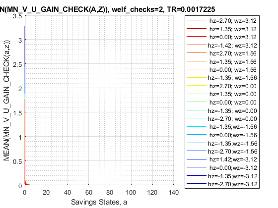

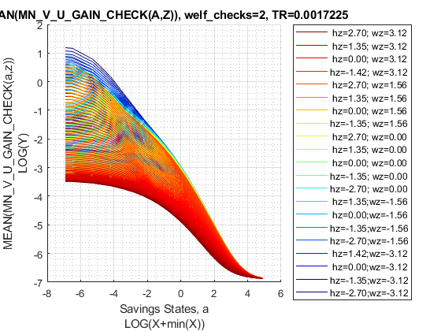

Graph Mean Consumption (*MPC: Share of Check Consumed*):

```
st_title = ['MEAN(MN\_MPC\_U\_GAIN\_CHECK(A,Z)), welf\_checks=' num2str(welf_checks) ', TR=' num2str(mp_params('TR')) ''];
mp_support_graph('cl_st_graph_title') = {st_title};
mp_support_graph('cl_st_ytitle') = {'MEAN(MN\_MPC\_U\_GAIN\_CHECK(a,z))'};
ff_graph_grid((tb_az_c{1:end, 3:end})', ar_st_eta_HS_grid, agrid, mp_support_graph);
```

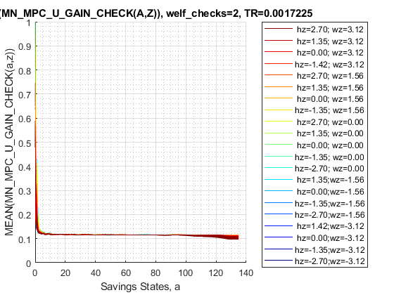

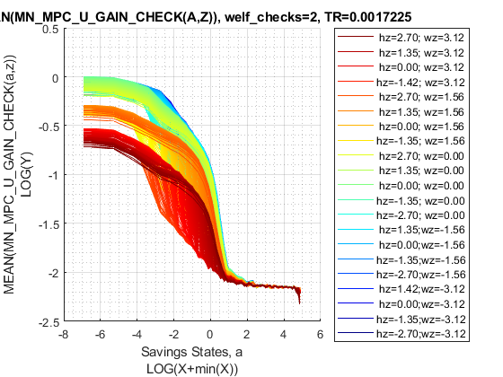

## 1.4 Analyze Kids and Marriage and Age

Aggregating over education, savings, and shocks, what are the differential effects of Marriage and Age.

```
% Generate some Data
mp_support_graph = containers.Map('KeyType', 'char', 'ValueType', 'any');
ar_row_grid = [...
    "k0M0", "K1M0", "K2M0", "K3M0", "K4M0", ...
    "k0M1", "K1M1", "K2M1", "K3M1", "K4M1"];
mp_support_graph('cl_st_xtitle') = {'Age'};
mp_support_graph('st_legend_loc') = 'best';
mp_support_graph('bl_graph_logy') = true; % do not log
mp_support_graph('st_rounding') = '6.2f'; % format shock legend
mp_support_graph('cl_scatter_shapes') = {...
    'o', 'd' ,'s', 'x', '*', ...
    'o', 'd', 's', 'x', '*'};
mp_support_graph('cl_colors') = {...
    'red', 'red', 'red', 'red', 'red'...
    'blue', 'blue', 'blue', 'blue', 'blue'};
```

MEAN(VAL(KM,J)), MEAN(AP(KM,J)), MEAN(C(KM,J))

Tabulate value and policies:

```
% Set
% NaN(n_jgrid,n_agrid,n_etagrid,n_educgrid,n_marriedgrid,n_kidsgrid);
ar_permute = [2,3,4,1,6,5];
% Value Function
st_title = ['MEAN(MN_V_U_GAIN_CHECK(KM,J)), welf_checks=' num2str(welf_checks) ', TR=' num2str(mp_params('TR'))];
tb_az_v = ff_summ_nd_array(st_title, mn_V_U_gain_check, true, ["mean"], 3, 1, cl_mp_datasetdesc, ar_permute);

xxx  MEAN(MN_V_U_GAIN_CHECK(KM,J)), welf_checks=2, TR=0.0017225  xxxxxxxxxxxxxxxxxxxxxxxxxxx
    group    kids    marry    mean_age_18    mean_age_19    mean_age_20    mean_age_21    mean_age_22    mean_age_23    mean_age_24    mean_age_25    mean_age_26    mean_age_27    mean_age_28    mean_age_29    mean_age_30    mean_age_31    mean_age_32    mean_age_33    mean_age_34    mean_age_35    …
    _____    ____    _____    ___________    ___________    ___________    ___________    ___________    ___________    ___________    ___________    ___________    ___________    ___________    ___________    ___________    ___________    ___________    ___________    ___________    ___________    …

      1       1        0        0.05653       0.055715       0.054794        0.04982       0.045679       0.042203       0.039266       0.036769       0.034633       0.032797       0.031213        0.029842       0.028652       0.027617       0.026716        0.02593       0.025246        0.02465     …
      2       2        0       0.078925       0.077839       0.076575       0.069564       0.063719       0.058807        0.05465       0.051107       0.048072       0.045457       0.043194        0.041231       0.039521       0.038029       0.036725       0.035583       0.034584       0.033709     …
      3       3        0       0.094952       0.093819        0.09245       0.084005       0.076969       0.071057       0.066055       0.061793       0.058142       0.054997       0.052276        0.049914       0.047856       0.046059       0.044489       0.043112       0.041906        0.04085     …
      4       4        0        0.10891         0.1077         0.1062        0.09651       0.088441       0.081662       0.075927       0.071041       0.066855       0.063249       0.060129         0.05742        0.05506          0.053       0.051197       0.049618       0.048233        0.04702     …
      5       5        0        0.12087        0.11965        0.11809        0.10735       0.098413       0.090907       0.084557        0.07915       0.074519       0.070531       0.067082        0.064089       0.061482       0.059207       0.057217       0.055474       0.053947       0.052609     …
      6       1        1       0.020237       0.019467       0.018733       0.016911       0.015385       0.014097       0.013008        0.01208       0.011283       0.010601       0.010014       0.0095067      0.0090696      0.0086922      0.0083662      0.0080852      0.0078432      0.0076361     …
      7       2        1       0.026775       0.025778       0.024831        0.02242       0.020395       0.018688       0.017243       0.016009       0.014952       0.014045       0.013262        0.012584       0.011997       0.011488       0.011048       0.010668        0.01034       0.010058     …
      8       3        1       0.032414       0.031263       0.030161       0.027239       0.024791       0.022728       0.020978       0.019483       0.018203       0.017105       0.016158        0.015337       0.014627       0.014012        0.01348       0.013019        0.01262       0.012277     …
      9       4        1       0.038629       0.037309       0.036028       0.032548       0.029638       0.027181       0.025097       0.023322         0.0218        0.02049       0.019358        0.018379        0.01753       0.016795       0.016158       0.015606       0.015127       0.014715     …
     10       5        1       0.047127       0.045665       0.044235       0.039997        0.03645       0.033474       0.030947       0.028781       0.026927       0.025338       0.023966        0.022775       0.021741       0.020846        0.02007       0.019398       0.018817       0.018314     …

% Consumption Function
st_title = ['MEAN(MN_MPC_U_GAIN_CHECK(KM,J)), welf_checks=' num2str(welf_checks) ', TR=' num2str(mp_params('TR'))];
tb_az_c = ff_summ_nd_array(st_title, mn_MPC_U_gain_share_check, true, ["mean"], 3, 1, cl_mp_datasetdesc, ar_permute);

```

[output cut: 14 more lines]

Graph Mean Values:

```
st_title = ['MEAN(MN\_V\_U\_GAIN\_CHECK(KM,J)), welf\_checks=' num2str(welf_checks) ', TR=' num2str(mp_params('TR')) ''];
mp_support_graph('cl_st_graph_title') = {st_title};
mp_support_graph('cl_st_ytitle') = {'MEAN(MN\_V\_U\_GAIN\_CHECK(KM,J))'};
ff_graph_grid((tb_az_v{1:end, 4:end}), ar_row_grid, age_grid, mp_support_graph);
```

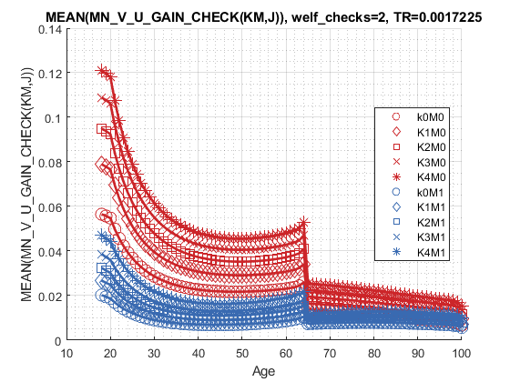

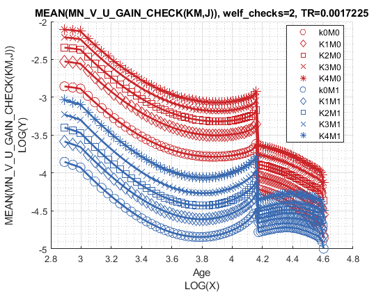

Graph Mean Consumption (*MPC: Share of Check Consumed*):

```
st_title = ['MEAN(MN\_MPC\_U\_GAIN\_CHECK(KM,J)), welf\_checks=' num2str(welf_checks) ', TR=' num2str(mp_params('TR')) ''];
mp_support_graph('cl_st_graph_title') = {st_title};
mp_support_graph('cl_st_ytitle') = {'MEAN(MN\_MPC\_U\_GAIN\_CHECK(KM,J))'};
ff_graph_grid((tb_az_c{1:end, 4:end}), ar_row_grid, age_grid, mp_support_graph);
```

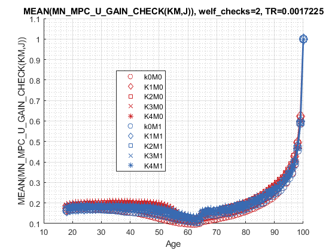

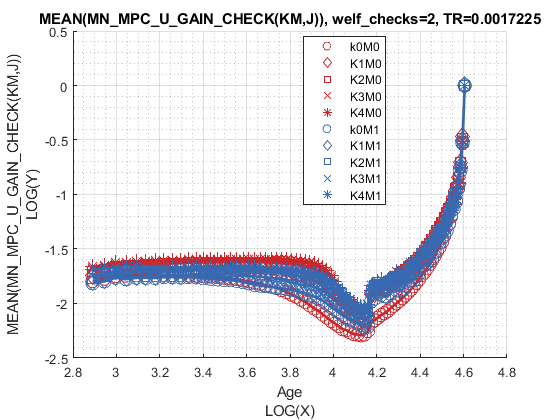

## 1.5 Analyze Education and Marriage

```
% Generate some Data
mp_support_graph = containers.Map('KeyType', 'char', 'ValueType', 'any');
ar_row_grid = ["E0M0", "E1M0", "E0M1", "E1M1"];
mp_support_graph('cl_st_xtitle') = {'Age'};
mp_support_graph('st_legend_loc') = 'best';
mp_support_graph('bl_graph_logy') = true; % do not log
mp_support_graph('st_rounding') = '6.2f'; % format shock legend
mp_support_graph('cl_scatter_shapes') = {'*', 'p', '*','p' };
mp_support_graph('cl_colors') = {'red', 'red', 'blue', 'blue'};
```

MEAN(VAL(EM,J)), MEAN(AP(EM,J)), MEAN(C(EM,J))

Tabulate value and policies:

```
% Set
% NaN(n_jgrid,n_agrid,n_etagrid,n_educgrid,n_marriedgrid,n_kidsgrid);
ar_permute = [2,3,6,1,4,5];
% Value Function
st_title = ['MEAN(MN_V_U_GAIN_CHECK(EM,J)), welf_checks=' num2str(welf_checks) ', TR=' num2str(mp_params('TR'))];
tb_az_v = ff_summ_nd_array(st_title, mn_V_U_gain_check, true, ["mean"], 3, 1, cl_mp_datasetdesc, ar_permute);

xxx  MEAN(MN_V_U_GAIN_CHECK(EM,J)), welf_checks=2, TR=0.0017225  xxxxxxxxxxxxxxxxxxxxxxxxxxx
    group    edu    marry    mean_age_18    mean_age_19    mean_age_20    mean_age_21    mean_age_22    mean_age_23    mean_age_24    mean_age_25    mean_age_26    mean_age_27    mean_age_28    mean_age_29    mean_age_30    mean_age_31    mean_age_32    mean_age_33    mean_age_34    mean_age_35    m…
    _____    ___    _____    ___________    ___________    ___________    ___________    ___________    ___________    ___________    ___________    ___________    ___________    ___________    ___________    ___________    ___________    ___________    ___________    ___________    ___________    _…

      1       0       0         0.0932       0.092347       0.091343       0.086009       0.081278       0.077067       0.073312       0.069956       0.066952       0.064255       0.061834       0.059658       0.057697       0.055932       0.054342       0.052908        0.051617       0.050454      …
      2       1       0       0.090875       0.089539       0.087898       0.076892       0.068011       0.060788        0.05487       0.049988       0.045937       0.042557       0.039723       0.037341       0.035332       0.033633       0.032195       0.030979         0.02995       0.029082      …
      3       0       1       0.034609       0.033465       0.032367       0.030037       0.027999       0.026213       0.024641       0.023251       0.022022       0.020936       0.019974       0.019119       0.018362       0.017693       0.017103       0.016582        0.016124       0.015721      …
      4       1       1       0.031464       0.030328       0.029228       0.025609       0.022664       0.020254       0.018268       0.016619       0.015244       0.014095       0.013129       0.012313       0.011623        0.01104       0.010546       0.010128       0.0097752      0.0094788      …

% Consumption
st_title = ['MEAN(MN_MPC_U_GAIN_CHECK(EM,J)), welf_checks=' num2str(welf_checks) ', TR=' num2str(mp_params('TR'))];
tb_az_c = ff_summ_nd_array(st_title, mn_MPC_U_gain_share_check, true, ["mean"], 3, 1, cl_mp_datasetdesc, ar_permute);

xxx  MEAN(MN_MPC_U_GAIN_CHECK(EM,J)), welf_checks=2, TR=0.0017225  xxxxxxxxxxxxxxxxxxxxxxxxxxx
    group    edu    marry    mean_age_18    mean_age_19    mean_age_20    mean_age_21    mean_age_22    mean_age_23    mean_age_24    mean_age_25    mean_age_26    mean_age_27    mean_age_28    mean_age_29    mean_age_30    mean_age_31    mean_age_32    mean_age_33    mean_age_34    mean_age_35    m…
    _____    ___    _____    ___________    ___________    ___________    ___________    ___________    ___________    ___________    ___________    ___________    ___________    ___________    ___________    ___________    ___________    ___________    ___________    ___________    ___________    _…

      1       0       0        0.17201        0.17468        0.17758        0.17848        0.17931        0.18009         0.1808        0.18147        0.18208        0.18264        0.18315         0.1836          0.184        0.18434        0.18462        0.18483        0.18498        0.18505       …
      2       1       0        0.18536        0.18966        0.19474        0.19608        0.19716        0.19801        0.19865        0.19909        0.19939        0.19954        0.19958        0.19951        0.19937        0.19914        0.19885         0.1985        0.19809         0.1976       …
      3       0       1        0.16432        0.16694        0.16991        0.16969        0.17077        0.17046        0.17082         0.1722        0.17223        0.17179        0.17276        0.17463        0.17366        0.17334        0.17296        0.17304        0.17362        0.17428       …
      4       1       1         0.1768        0.17996        0.18466        0.18422         0.1859         0.1855        0.18572        0.18794        0.18585        0.18528        0.18635        0.18682        0.18525        0.18478         0.1849        0.18505        0.18442        0.18397       …
```

Graph Mean Values:

```
st_title = ['MEAN(MN\_V\_U\_GAIN\_CHECK(EM,J)), welf\_checks=' num2str(welf_checks) ', TR=' num2str(mp_params('TR')) ''];
mp_support_graph('cl_st_graph_title') = {st_title};
mp_support_graph('cl_st_ytitle') = {'MEAN(MN\_V\_U\_GAIN\_CHECK(EM,J))'};
ff_graph_grid((tb_az_v{1:end, 4:end}), ar_row_grid, age_grid, mp_support_graph);
```

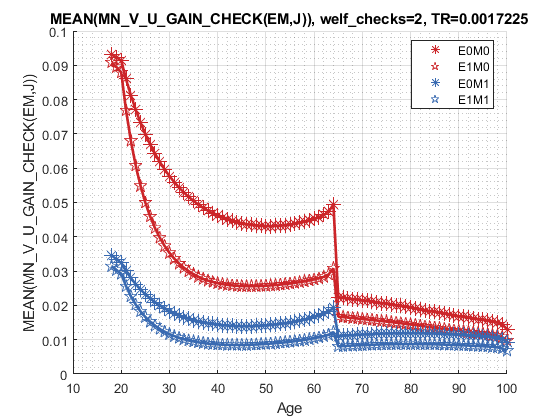

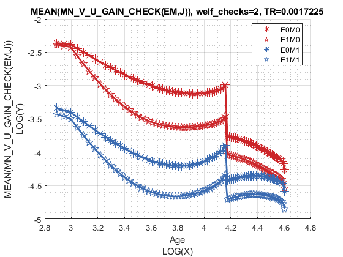

Graph Mean Consumption (*MPC: Share of Check Consumed*):

```
st_title = ['MEAN(MN\_MPC\_U\_GAIN\_CHECK(EM,J)), welf\_checks=' num2str(welf_checks) ', TR=' num2str(mp_params('TR')) ''];
mp_support_graph('cl_st_graph_title') = {st_title};
mp_support_graph('cl_st_ytitle') = {'MEAN(MN\_MPC\_U\_GAIN\_CHECK(EM,J))'};
ff_graph_grid((tb_az_c{1:end, 4:end}), ar_row_grid, age_grid, mp_support_graph);
```

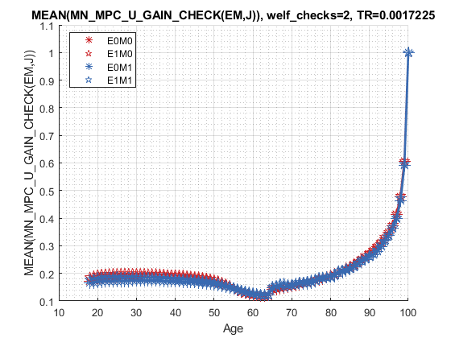

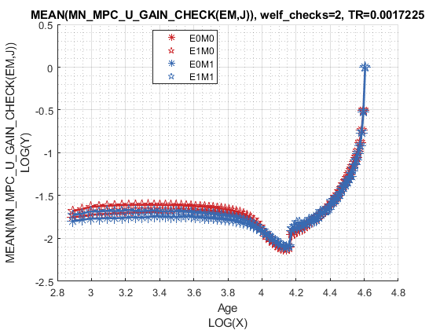